# M2_AI1: Precio de la gasolina

#### Autor: Leandro Gutierrez

#### Este documento intenta dar respuesta a la actividad 1 propuesta en el Modulo **Fundamentos de Estadística** del **Master en Big Data y Ciencia de Datos**. En él se describirán cada uno de los enunciados postulados y los resultados obtenidos utilizando Python y Google Colab.

#### Junio 09, 2024

## Enunciado

1. ```
   Indica el número total de observaciones y variables totales en el dataset. Calcula el número de nulos de cada variable. ¿Qué aporta esta información? (10%)
   ```

2. ```
   Identifica el tipo de variables a nivel estadístico que corresponden cada una del dataset. Debes explicar el motivo por el cual haces dicha clasificación. (30%)
   ```

3. ```
   Crear una tabla de frecuencias y el gráfico correspondiente para cada una de las variables siguientes: provincia, margen y precio. (60%)
   ```

## Solución

### Diccionario de datos

[output not shown]

### Enunciado 1

#### Carga de datos

```python
# Importando las librerias
import pandas as pd
import matplotlib.pyplot as plt

# Definición de la url de los datos
url = 'https://github.com/md-lorente/data/blob/master/precio_gasolina.csv?raw=true'

# Creacion Dataframe
df_org = pd.read_csv(url, sep=';', decimal=',')
```

```python
# Visualización del dataframe (la cabecera)
df_org.head()
```

|  | Provincia | Localidad | Codigo_postal | Direccion | Margen | Toma_de_datos | Precio | Rotulo | Tipo_venta | Rem | Horario | Tipo_servicio | Fecha_extraccion |
| --- | --- | --- | --- | --- | --- | --- | --- | --- | --- | --- | --- | --- | --- |
| 0 | SANTA CRUZ DE TENERIFE | CUESTA LA | 38320 | AVENIDA LOS MENCEYES 223 | D | 01 08 2020 1353 | 0.758 | PCAN | P | dm | LD 24H | LD 24H A | 01 08 2020 |
| 1 | SANTA CRUZ DE TENERIFE | LA LAGUNA | 38200 | CARRETERA TF111 KM 8 346 | D | 01 08 2020 0900 | 0.759 | OCEANO | P | dm | LS 06002200 D 07002200 | LS 06002200 A D 07002200 A | 01 08 2020 |
| 2 | SANTA CRUZ DE TENERIFE | SANTA CRUZ DE TENERIFE | 38110 | CALLE LAURA GROTE DE LA PUERTA 2 | D | 27 07 2020 1202 | 0.769 | GMOIL | P | dm | LV 24H S 06002000 D 08001500 | LV 24H A S 06002000 A D 08001500 A | 01 08 2020 |
| 3 | SANTA CRUZ DE TENERIFE | SANTA CRUZ DE TENERIFE | 38010 | POLIGONO EL MAYORAZGO SN | N | 29 07 2020 0000 | 0.789 | TGASTU TREBOL | P | dm | LS 07302100 D 08001400 | LS 07302100 A D 08001400 A | 01 08 2020 |
| 4 | SANTA CRUZ DE TENERIFE | ADEJE | 38670 | CALLE CHARFA ESQUINA AVENIDA LAS PALMITAS SN | D | 27 07 2020 1159 | 0.789 | GMOIL | P | dm | LS 07002200 D 09001600 | LS 07002200 A D 09001600 A | 01 08 2020 |

```python
df_aux = df_org.copy()

# Resumen información del fichero
print(df_aux.info())
```

```
<class 'pandas.core.frame.DataFrame'>
RangeIndex: 9991 entries, 0 to 9990
Data columns (total 13 columns):
 #   Column            Non-Null Count  Dtype
---  ------            --------------  -----
 0   Provincia         9991 non-null   object
 1   Localidad         9991 non-null   object
 2   Codigo_postal     9991 non-null   int64
 3   Direccion         9991 non-null   object
 4   Margen            9991 non-null   object
 5   Toma_de_datos     9991 non-null   object
 6   Precio            9991 non-null   float64
 7   Rotulo            9990 non-null   object
 8   Tipo_venta        9991 non-null   object
 9   Rem               9991 non-null   object
 10  Horario           9991 non-null   object
 11  Tipo_servicio     9845 non-null   object
 12  Fecha_extraccion  9991 non-null   object
dtypes: float64(1), int64(1), object(11)
memory usage: 1014.8+ KB
None
```

#### Análisis del dataset

```python
df_aux.shape
```

```
(9991, 13)
```

Nuestro dataset cuenta con un total de 9991 observaciones y 13 variables.

#### Análisis de calidad del dataset

```python
df_aux.isna().sum()
```

```
Provincia             0
Localidad             0
Codigo_postal         0
Direccion             0
Margen                0
Toma_de_datos         0
Precio                0
Rotulo                1
Tipo_venta            0
Rem                   0
Horario               0
Tipo_servicio       146
Fecha_extraccion      0
dtype: int64
```

Como primera instancia en nuestro análisis debemos conocer la calidad de nuestros datos, entre los puntos a analizar está la completitud de nuestra información, es decir la cantidad de datos nulos o faltantes. En este caso podemos observar que la variable **Tipo de servicio** contiene 146 valores nulos entre los 9991 observaciones realizadas. Mientras que la variable **Rotulo** muestra un elemento faltante. Es nuestra tarea en función de esta información definir como tratamos a estos faltantes.

### Enunciado 2

#### Análisis de los tipos de variables

1. Provincia: provincia en la que se encuentra la gasolinera donde se tomó la observacion. La variable representa la región geográfica y no existe un orden epecífica o jerarquía. Es una variable cualitativa nominal.
2. Localidad: localidad en la que se encuentra la gasolinera donde se tomó la observacion. No sigue un orden o jerarquía. Es una variable cualitativa nominal.
3. Codigo postal: indentifica el área donde se encuentra la gasolinera donde se tomó la observación. A pesar de ser numérica no se puede utilizar para operaciones algebraicas, y sirve para agrupar y clasificar nuestras observaciones. Es una variable cualitativa nominal.
4. Dirección: ubicación especifica de la gasolinera donde se tomó la observacion. No posee un orden o jerarquía. Es una variable cualitativa nominal.
5. Margen: margen de la carretera en el que se encuentra la gasolinera. No posee orden específico. Es una variable cualitativa nominal.
6. Toma de datos: fecha en la que **Geoportal** tomó el dato. El mecanismo de generación del archivo indica que se toman mediciones cada hora y las nuevas observaciones sobreescriben las anteriores actualizando esta variable. Si bien es una variable numérica, puede ser tratada como cualitativa, ya que puede servir para clasificar y agrupar información, por ejemplo por años/meses/trimestres. Cabe mencionar que existen operaciones donde estas variables se pueden computar, por ejemplo al transformar el dato a minutos o segundos desde el **epoch** y al operar con multiples observaciones podemos obtener una duración o período. Va a depender del tipo de análisis que se haga y de los datos con los que se cuente. En este caso, al tener una única medición por gasolinera impidiendonos el análisis temporal, vamos a considerar la variable como cualitativa ordinal.
7. Precio: precio del galon de gasolina de 95 octanos. Es un valor numérico continuo. Es una variable cuantitativa continua.
8. Rotulo: nombre comercial de la gasolinera. No posee un orden específico jerarquía. Es una variable cualitativa nominal.
9. Tipo de venta: indica si la venta es a público general o restringida a socios. Es una variable categórica que nos permite agrupar los datos, a su vez posee solo dos valores posibles. Es una variable dicotómica simétrica. Es simétrica ya que no determina presencia/ausencia, sino que determina dos estados cualesquiera.
10. Rem: indica si la observación procede de distribuidor mayorista o minorista. Sirve para clasificar y agrupar las observaciones. y cuenta con dos valores posibles. Es una variable dicotómica simétrica. Es simétrica ya que no determina presencia/ausencia, sino que determina dos estados cualesquiera.
11. Horario: indica horario de atención de la gasolinera. Sirve para agrupar y clasificar las observaciones. No posee orden específico. Es una variable cualitatica nominal.
12. Tipo de servicio: indica la forma de atención de la gasolinera en cada uno de los tramos horarios. Permite agrupar y clasificar las observaciones y no posee un orden específico. Es una variable cualitativa nominal.
13. Fecha de extraccion: indica fecha de la toma el dato de **Geoportal**. Como se mencionó anteriormente la tabla publicada es dinámica y tiene una frecuencia de actualización de una hora, por lo que los datos obtenidos van a varirar dependiendo del momento de la toma de la información desde el portal. Podemos observar que todas las filas tienen idéntica fecha de extracción por lo que podemos asumir que los datos corresponden a un único barrido de adquisición. Las fechas pueden ser consideradas cualitativas ya que sirve para agrupar nuestras mediciones. En este caso opearar sobre estas fechas o sobre su equivalente en **epoch** para obtener duraciones queda descartado ya que aportaría nada al análisis. A su vez no contamos con el histórico de mediciones, por lo que utilizar la variable para analisis temporal queda descartado. Es una variable cualitativa nominal.

### Enunciado 3

#### Análisis de la variable Provincia

```python
# determinamos frecuencias absolutas y relativas de cada provincia
frecuencia_prov_abs = df_aux['Provincia'].value_counts().sort_index()
frecuencia_prov_rel = df_aux['Provincia'].value_counts(normalize=True).sort_index()
```

```python
# determinamos frecuencias acumuladas absolutas y relativas de cada provincia
frecuencia_prov_abs_acum = frecuencia_prov_abs.cumsum()
frecuencia_prov_rel_acum = frecuencia_prov_rel.cumsum()
```

```python
# creamos un nuevo dataframe de frecuencias para la variable provincia
frecuencias_prov = pd.DataFrame({
    'ni': frecuencia_prov_abs,
    'Ni': frecuencia_prov_abs_acum,
    'fi': frecuencia_prov_rel,
    'Fi': frecuencia_prov_rel_acum
})

frecuencias_prov
```

|  | ni | Ni | fi | Fi |
| --- | --- | --- | --- | --- |
| ALBACETE | 133 | 133 | 0.013312 | 0.013312 |
| ALICANTE | 408 | 541 | 0.040837 | 0.054149 |
| ALMERIA | 184 | 725 | 0.018417 | 0.072565 |
| ARABA ALAVA | 61 | 786 | 0.006105 | 0.078671 |
| ASTURIAS | 203 | 989 | 0.020318 | 0.098989 |
| AVILA | 62 | 1051 | 0.006206 | 0.105195 |
| BADAJOZ | 207 | 1258 | 0.020719 | 0.125913 |
| BALEARS ILLES | 194 | 1452 | 0.019417 | 0.145331 |
| BARCELONA | 723 | 2175 | 0.072365 | 0.217696 |
| BIZKAIA | 117 | 2292 | 0.011711 | 0.229406 |
| BURGOS | 129 | 2421 | 0.012912 | 0.242318 |
| CACERES | 131 | 2552 | 0.013112 | 0.255430 |
| CADIZ | 244 | 2796 | 0.024422 | 0.279852 |
| CANTABRIA | 143 | 2939 | 0.014313 | 0.294165 |
| CASTELLON CASTELLO | 172 | 3111 | 0.017215 | 0.311380 |
| CEUTA | 9 | 3120 | 0.000901 | 0.312281 |
| CIUDAD REAL | 183 | 3303 | 0.018316 | 0.330598 |
| CORDOBA | 195 | 3498 | 0.019518 | 0.350115 |
| CORUNA A | 257 | 3755 | 0.025723 | 0.375838 |
| CUENCA | 107 | 3862 | 0.010710 | 0.386548 |
| GIPUZKOA | 112 | 3974 | 0.011210 | 0.397758 |
| GIRONA | 243 | 4217 | 0.024322 | 0.422080 |
| GRANADA | 250 | 4467 | 0.025023 | 0.447102 |
| GUADALAJARA | 80 | 4547 | 0.008007 | 0.455110 |
| HUELVA | 120 | 4667 | 0.012011 | 0.467120 |
| HUESCA | 104 | 4771 | 0.010409 | 0.477530 |
| JAEN | 225 | 4996 | 0.022520 | 0.500050 |
| LEON | 159 | 5155 | 0.015914 | 0.515964 |
| LLEIDA | 166 | 5321 | 0.016615 | 0.532579 |
| LUGO | 118 | 5439 | 0.011811 | 0.544390 |
| MADRID | 730 | 6169 | 0.073066 | 0.617456 |
| MALAGA | 296 | 6465 | 0.029627 | 0.647082 |
| MELILLA | 13 | 6478 | 0.001301 | 0.648384 |
| MURCIA | 384 | 6862 | 0.038435 | 0.686818 |
| NAVARRA | 202 | 7064 | 0.020218 | 0.707036 |
| OURENSE | 80 | 7144 | 0.008007 | 0.715044 |
| PALENCIA | 62 | 7206 | 0.006206 | 0.721249 |
| PALMAS LAS | 231 | 7437 | 0.023121 | 0.744370 |
| PONTEVEDRA | 184 | 7621 | 0.018417 | 0.762787 |
| RIOJA LA | 70 | 7691 | 0.007006 | 0.769793 |
| SALAMANCA | 96 | 7787 | 0.009609 | 0.779401 |
| SANTA CRUZ DE TENERIFE | 223 | 8010 | 0.022320 | 0.801722 |
| SEGOVIA | 71 | 8081 | 0.007106 | 0.808828 |
| SEVILLA | 385 | 8466 | 0.038535 | 0.847363 |
| SORIA | 36 | 8502 | 0.003603 | 0.850966 |
| TARRAGONA | 212 | 8714 | 0.021219 | 0.872185 |
| TERUEL | 62 | 8776 | 0.006206 | 0.878391 |
| TOLEDO | 235 | 9011 | 0.023521 | 0.901912 |
| VALENCIA | 568 | 9579 | 0.056851 | 0.958763 |
| VALLADOLID | 127 | 9706 | 0.012711 | 0.971474 |
| ZAMORA | 73 | 9779 | 0.007307 | 0.978781 |
| ZARAGOZA | 212 | 9991 | 0.021219 | 1.000000 |

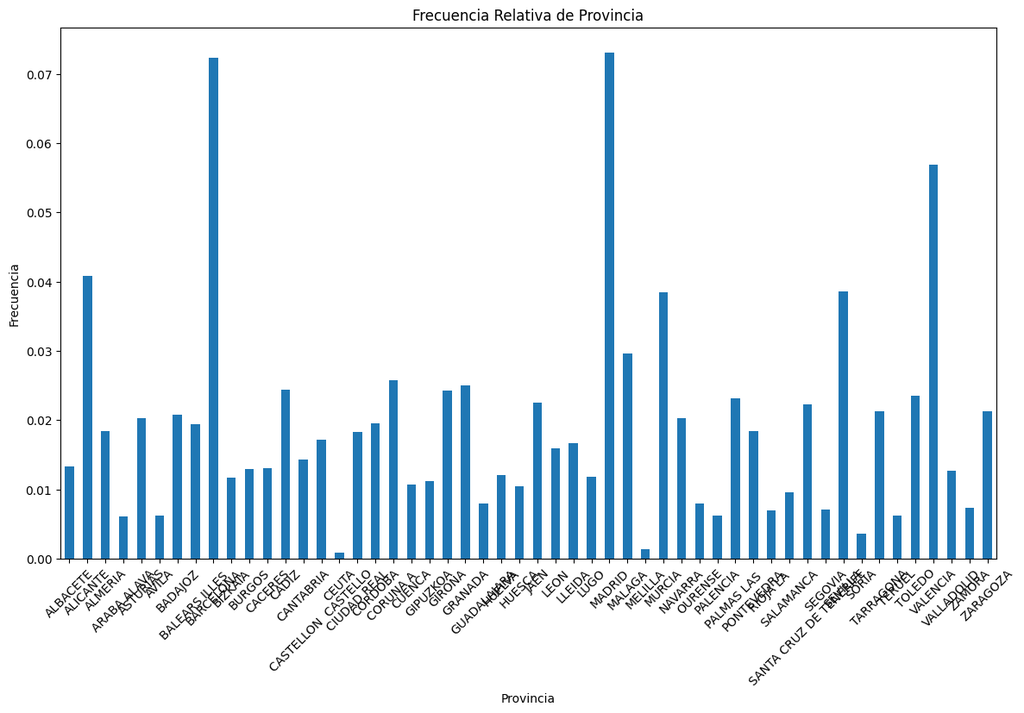

```python
# creamos un diagrama de barras para la visualizar las frecuencias relativas de la variable Provincia
plt.figure(figsize=(14, 8))
frecuencia_prov_rel.plot(kind='bar')
plt.title('Frecuencia Relativa de Provincia')
plt.xlabel('Provincia')
plt.ylabel('Frecuencia')
plt.xticks(rotation=45)
plt.show()
```

Obs: Trataremos de mejorar la visualización

```python
frecuencia_prov_rel.size
```

```
52
```

Podemos observar que existen 52 provincias de las que se tienen observaciones, dicho numero hace dificil el análisis gráfico. Para simplificar la visualización tomaremos el quantil 0.9 de frecuencias relativas. Cabe destacar que en este analisis no se modifica el dataset original quitando datos, solo se descartan las frecuencias relaticas menos significativas para una mejor visualización.

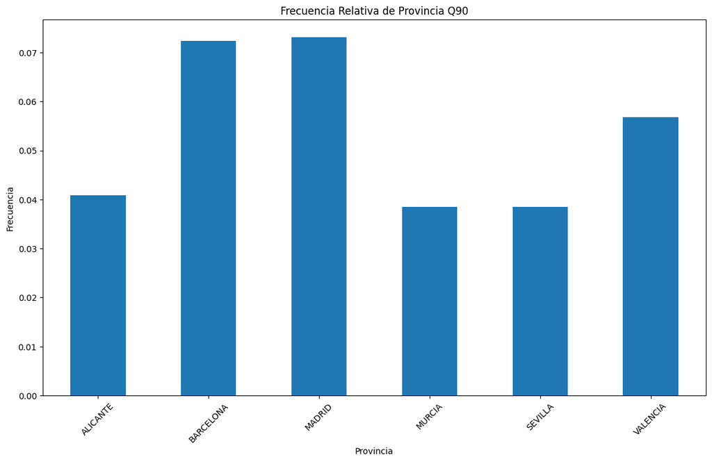

```python
# Obtenemos el quantil 0.9
q = frecuencia_prov_rel.quantile(0.90)

# obtenemos el subset
frecencuas_prov_clean = frecuencia_prov_rel[frecuencia_prov_rel > q].copy()

# creamos un diagrama de barras para la visualizar las frecuencias relativas de la variable Provincia
plt.figure(figsize=(14, 8))
frecencuas_prov_clean.plot(kind='bar')
plt.title('Frecuencia Relativa de Provincia Q90')
plt.xlabel('Provincia')
plt.ylabel('Frecuencia')
plt.xticks(rotation=45)
plt.show()
```

#### Análisis de la variable Margen

```python
# determinamos frecuencias absolutas y relativas de margen
frecuencia_margen_abs = df_aux['Margen'].value_counts().sort_index()
frecuencia_margen_rel = df_aux['Margen'].value_counts(normalize=True).sort_index()
```

```python
# determinamos frecuencias acumuladas absolutas y relativas de cada margen
frecuencia_margen_abs_acum = frecuencia_margen_abs.cumsum()
frecuencia_margen_rel_acum = frecuencia_margen_rel.cumsum()
```

```python
# creamos un nuevo dataframe de frecuencias para la variable provincia
frecuencias_margen = pd.DataFrame({
    'ni': frecuencia_margen_abs,
    'Ni': frecuencia_margen_abs_acum,
    'fi': frecuencia_margen_rel,
    'Fi': frecuencia_margen_rel_acum
})

frecuencias_margen
```

|  | ni | Ni | fi | Fi |
| --- | --- | --- | --- | --- |
| D | 5016 | 5016 | 0.502052 | 0.502052 |
| I | 2596 | 7612 | 0.259834 | 0.761886 |
| N | 2379 | 9991 | 0.238114 | 1.000000 |

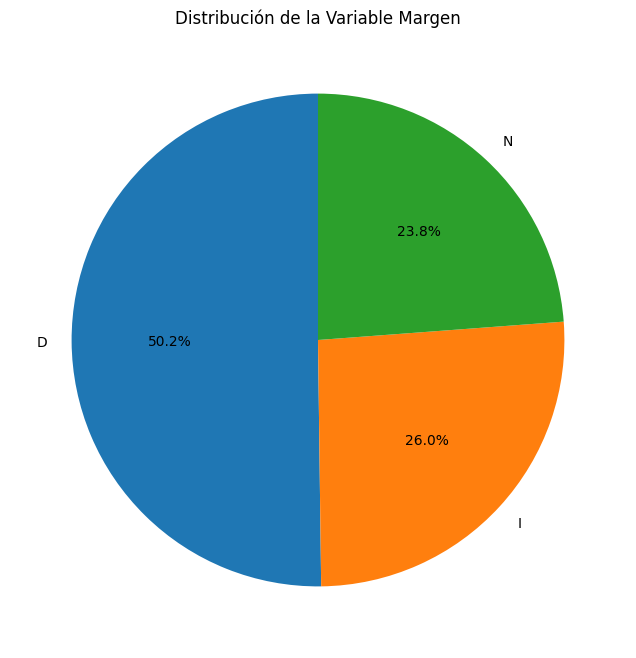

```python
# creamos un diagrama de torta para la visualizar las frecuencias relativas de la variable Margen
plt.figure(figsize=(8, 8))
frecuencia_margen_rel.plot(kind='pie', autopct='%1.1f%%', startangle=90)
plt.title('Distribución de la Variable Margen')
plt.ylabel('')  # Esto elimina la etiqueta de y para que el gráfico se vea mejor
plt.show()
```

#### Análisis de la variable Precio

Para el análisis de la variable cuantitativa continua **Precio** vamos a utilizar la *distribución de frecuencias agrupadas*. Para ello vamos a determinar intervalos o clases en los cuales se agruparan nuestras observaciones y asignaremos una frecuencia absoluta y relativa a cada uno de estas clases según corresponda.

Para determiar el número de clases podemos utilizar dos fórmulas dependiendo del numero de observaciones:

1. Si N no es grande: $$ \sqrt{N} $$
2. Si N es grande: $$ 1 + 3.22 * log_{10}N $$

En este caso contamos con 9991 observaciones que si bien puede no parecer un número grande, la primera fórmula nos entregaría un total de 100 clases, lo cual dificultaría el análisis.

Vamos a utilizar la segunda fórmula tambien conocida como **Regla de Sturges** para determinar la canitdad total de clases o intervalos a considerar. Quedando:

$$ \begin{align*} Clases &= 1 + 3.22 * log_{10}9991\\ Clases &= 1 + 12.87\\ Clases &= 13.87\\ Clases &\approx 14\\ \end{align*} $$

```python
# definimos la cantidad de tramos
num_tramos = 14
# agregamos una columna que agrupe determine a que clase/tramo pertenece cada medición
df_aux['Precio_tramos'] = pd.cut(df_aux['Precio'], num_tramos)
```

```python
# determinamos frecuencias absolutas y relativas de cada tramo
frecuencia_precio_abs = df_aux['Precio_tramos'].value_counts().sort_index()
frecuencia_precio_rel = df_aux['Precio_tramos'].value_counts(normalize=True).sort_index()
```

```python
# determinamos las frecuencias acumuladas para cada tramo
frecuencia_precio_abs_acum = frecuencia_precio_abs.cumsum()
frecuencia_precio_rel_acum = frecuencia_precio_rel.cumsum()
```

```python
# creamos un nuevo dataframe de frecuencias para la variable precio
frecuencias_precio = pd.DataFrame({
    'ni': frecuencia_precio_abs,
    'Ni': frecuencia_precio_abs_acum,
    'fi': frecuencia_precio_rel,
    'Fi': frecuencia_precio_rel_acum
})

frecuencias_precio
```

|  | ni | Ni | fi | Fi |
| --- | --- | --- | --- | --- |
| (0.757, 0.807] | 6 | 6 | 0.000601 | 0.000601 |
| (0.807, 0.857] | 29 | 35 | 0.002903 | 0.003503 |
| (0.857, 0.906] | 112 | 147 | 0.011210 | 0.014713 |
| (0.906, 0.955] | 86 | 233 | 0.008608 | 0.023321 |
| (0.955, 1.004] | 240 | 473 | 0.024022 | 0.047343 |
| (1.004, 1.054] | 456 | 929 | 0.045641 | 0.092984 |
| (1.054, 1.103] | 1124 | 2053 | 0.112501 | 0.205485 |
| (1.103, 1.152] | 1427 | 3480 | 0.142829 | 0.348313 |
| (1.152, 1.202] | 3721 | 7201 | 0.372435 | 0.720749 |
| (1.202, 1.251] | 2543 | 9744 | 0.254529 | 0.975278 |
| (1.251, 1.3] | 241 | 9985 | 0.024122 | 0.999399 |
| (1.3, 1.349] | 4 | 9989 | 0.000400 | 0.999800 |
| (1.349, 1.399] | 0 | 9989 | 0.000000 | 0.999800 |
| (1.399, 1.448] | 2 | 9991 | 0.000200 | 1.000000 |

Para visualizar la distribución de frecuencias utilizaremos un diagrama de barras con frecuencias relativas, ya que aporta mayor contexto al análisis.

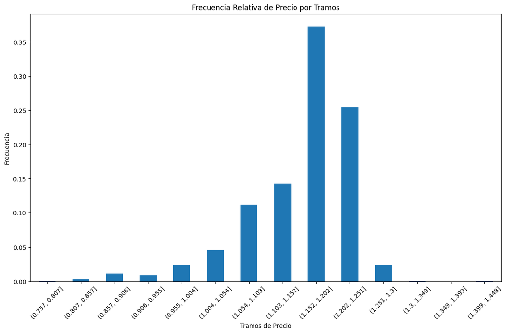

```python
# creamos un histograma para la visualizar las frecuencias relativas de la variable precio
plt.figure(figsize=(14, 8))
frecuencia_precio_rel.plot(kind='bar')
# plt.hist(df_aux['Precio'], bins=14, edgecolor='black')
plt.title('Frecuencia Relativa de Precio por Tramos')
plt.xlabel('Tramos de Precio')
plt.ylabel('Frecuencia')
plt.xticks(rotation=45)
plt.show()
```